# Caffeine and ADHD Meta-Analysis Effect Sizes

# Load Package

```r
if (!require(esc)){
  install.packages("esc", dependencies = TRUE)
  require(esc)
}
library(esc)
```

# Converting effect sizes to correlation effect size r

### A gender-specific analysis of adolescent dietary caffeine, alcohol consumption, anger, and violent behavior

#### Study 1 - Males

##### standardized regression coefficient to r

```r
esc_beta(beta = 0.13,   # standardized regression coefficient
         sdy = 1.35,       # standard deviation of predicted variable y
         grp1n = 256,    # sample size of the first group
         grp2n = 1572,    # sample size of the second group
         es.type = "r") # convert to correlation
```

```
Effect Size Calculation for Meta Analysis

     Conversion: standardized regression coefficient to effect size correlation
    Effect Size:   0.1299
 Standard Error:   0.0235
       Variance:   0.0006
       Lower CI:   0.0844
       Upper CI:   0.1749
         Weight: 1813.4387
     Fisher's z:   0.1307
      Lower CIz:   0.0846
      Upper CIz:   0.1767
```

#### Study 2 - Females

##### standardized regression coefficient to r

```r
esc_beta(beta = 0.18,   # standardized regression coefficient
         sdy = 0.74,       # standard deviation of predicted variable y
         grp1n = 166,    # sample size of the first group
         grp2n = 1676,    # sample size of the second group
         es.type = "r") # convert to correlation
```

```
Effect Size Calculation for Meta Analysis

     Conversion: standardized regression coefficient to effect size correlation
    Effect Size:   0.1799
 Standard Error:   0.0235
       Variance:   0.0006
       Lower CI:   0.1350
       Upper CI:   0.2241
         Weight: 1812.7006
     Fisher's z:   0.1819
      Lower CIz:   0.1359
      Upper CIz:   0.2279
```

### Energy drinks and youth self-reported hyperactivity/inattention symptoms

#### Study 3

##### chi-squared value to r

```r
esc_chisq(p = .004, # p value
          totaln = 1649, # total sample size
          es.type = "r") # convert to correlation
```

```
Effect Size Calculation for Meta Analysis

     Conversion: chi-squared-value to effect size correlation
    Effect Size:   0.0709
 Standard Error:   0.0247
       Variance:   0.0006
       Lower CI:   0.0226
       Upper CI:   0.1188
         Weight: 1641.7162
     Fisher's z:   0.0710
      Lower CIz:   0.0226
      Upper CIz:   0.1194
```

### Energy Drink Use in Adolescents With and Without ADHD: Trends and Influences

#### Study 4 - adolescents

##### chi-squared value to r

```r
esc_chisq(chisq = .167,   # chi square value
          p = .197,   # p value
          totaln = 72,  # total sample size
          es.type = "r")  # convert to correlation
```

```
Effect Size Calculation for Meta Analysis

     Conversion: chi-squared-value to effect size correlation
    Effect Size:   0.0482
 Standard Error:   0.1172
       Variance:   0.0137
       Lower CI:  -0.1795
       Upper CI:   0.2709
         Weight:  72.8330
     Fisher's z:   0.0482
      Lower CIz:  -0.1815
      Upper CIz:   0.2779
```

#### Study 5 - parents

##### chi-squared value to r

```r
esc_chisq(chisq = .058,  # chi square value
          p = .809, # p value
          totaln = 69, # total sample size
          es.type = "r") # convert to correlation
```

```
Effect Size Calculation for Meta Analysis

     Conversion: chi-squared-value to effect size correlation
    Effect Size:   0.0290
 Standard Error:   0.1196
       Variance:   0.0143
       Lower CI:  -0.2025
       Upper CI:   0.2574
         Weight:  69.9420
     Fisher's z:   0.0290
      Lower CIz:  -0.2054
      Upper CIz:   0.2634
```

### Exploring the Role of Caffeine Use in Adult-ADHD Symptom Severity of US Army Soldiers

#### Study 6

#####chi-squared value to r

```r
esc_chisq(chisq = 143.27, # chi square value
          p = .00001, # p value
          totaln = 18913, # total sample size
          es.type = "r") # convert to correlation
```

```
Effect Size Calculation for Meta Analysis

     Conversion: chi-squared-value to effect size correlation
    Effect Size:   0.0870
 Standard Error:   0.0073
       Variance:   0.0001
       Lower CI:   0.0728
       Upper CI:   0.1012
         Weight: 18770.7300
     Fisher's z:   0.0873
      Lower CIz:   0.0730
      Upper CIz:   0.1016
```

### Self-Medication of ADHD Symptoms: Does Caffeine Have a Role?

#### Study 7

##### r is already given (0.015)

##### chi-squared value to r

```r
esc_chisq(chisq = 0.942, # chi square value
          p = .8015, # p value
          totaln = 2259, # total sample size
          es.type = "r") # convert to correlation
```

```
Effect Size Calculation for Meta Analysis

     Conversion: chi-squared-value to effect size correlation
    Effect Size:   0.0204
 Standard Error:   0.0210
       Variance:   0.0004
       Lower CI:  -0.0208
       Upper CI:   0.0616
         Weight: 2259.0580
     Fisher's z:   0.0204
      Lower CIz:  -0.0208
      Upper CIz:   0.0617
```

## combine effect sizes into one dataframe

### make lists

```r
## e1
  e1 = esc_beta(beta = 0.13,   # standardized regression coefficient
                sdy = 1.35,       # standard deviation of predicted variable y
                grp1n = 256,    # sample size of the first group
                grp2n = 1572,    # sample size of the second group
                es.type = "r",   # convert to correlation
                study = "Males: A gender-specific analysis of adolescent dietary caffeine, alcohol consumption, anger, and violent behavior") # Study Name
## e2
  e2 = esc_beta(beta = 0.18,   # standardized regression coefficient
                sdy = 0.74,       # standard deviation of predicted variable y
                grp1n = 166,    # sample size of the first group
                grp2n = 1676,    # sample size of the second group
                es.type = "r", # convert to correlation
                study = "Females: A gender-specific analysis of adolescent dietary caffeine, alcohol consumption, anger, and violent behavior") # Study Name
## e3
  e3 = esc_chisq(p = .004, # p value
                 totaln = 1649, # total sample size
                 es.type = "r", # convert to correlation
                 study = "Energy drinks and youth self-reported hyperactivity/inattention symptoms") # study name
## e4
  e4 = esc_chisq(chisq = .167,   # chi square value
                 p = .197,   # p value
                 totaln = 72,  # total sample size
                 es.type = "r",  # convert to correlation
                 study = "Adolescents: Energy Drink Use in Adolescents With and Without ADHD: Trends and Influences") # Study Name
## e5
  e5 = esc_chisq(chisq = .058,  # chi square value
                 p = .809, # p value
                 totaln = 69, # total sample size
                 es.type = "r", # convert to correlation
                 study = "Parents: Energy Drink Use in Adolescents With and Without ADHD: Trends and Influences") # study name
## e6
  e6 = esc_chisq(chisq = 143.27, # chi square value
                 p = .00001, # p value
                 totaln = 18913, # total sample size
                 es.type = "r", # convert to correlation
                 study = "Exploring the Role of Caffeine Use in Adult-ADHD Symptom Severity of US Army Soldiers") # study name
## e7
  e7 = esc_chisq(chisq = 0.942, # chi square value
                 p = .8015, # p value
                 totaln = 2259, # total sample size
                 es.type = "r", # convert to correlation
                 study = "Self-Medication of ADHD Symptoms: Does Caffeine Have a Role?") # study name
```

### make dataframe

```r
### SCROLL TO THE RIGHT TO VIEW STATS
es_df = combine_esc(e1, e2, e3, e4, e5, e6, e7)
es_df
```

| study | es | weight | sample.size | se | var | ci.lo | ci.hi | fishers.z | ci.lo.z | ci.hi.z | measure |
| --- | --- | --- | --- | --- | --- | --- | --- | --- | --- | --- | --- |
| Males: A gender-specific analysis of adolescent dietary caffeine, alcohol consumption, anger, and violent behavior | 0.12993007 | 1813.439 | 1828 | 0.023482729 | 5.514386e-04 | 0.08444185 | 0.17487785 | 0.13066871 | 0.08464341 | 0.17669402 | r |
| Females: A gender-specific analysis of adolescent dietary caffeine, alcohol consumption, anger, and violent behavior | 0.17990542 | 1812.701 | 1842 | 0.023487509 | 5.516631e-04 | 0.13502067 | 0.22405332 | 0.18188494 | 0.13585027 | 0.22791961 | r |
| Energy drinks and youth self-reported hyperactivity/inattention symptoms | 0.07087693 | 1641.716 | 1649 | 0.024680330 | 6.091187e-04 | 0.02261955 | 0.11880478 | 0.07099597 | 0.02262341 | 0.11936853 | r |
| Adolescents: Energy Drink Use in Adolescents With and Without ADHD: Trends and Influences | 0.04816061 | 72.833 | 72 | 0.117175253 | 1.373004e-02 | -0.17949553 | 0.27092069 | 0.04819790 | -0.18146138 | 0.27785717 | r |
| Parents: Energy Drink Use in Adolescents With and Without ADHD: Trends and Influences | 0.02899275 | 69.942 | 69 | 0.119572408 | 1.429756e-02 | -0.20251789 | 0.25743415 | 0.02900088 | -0.20535673 | 0.26335849 | r |
| Exploring the Role of Caffeine Use in Adult-ADHD Symptom Severity of US Army Soldiers | 0.08703570 | 18770.730 | 18913 | 0.007298934 | 5.327443e-05 | 0.07282169 | 0.10121436 | 0.08725647 | 0.07295083 | 0.10156212 | r |
| Self-Medication of ADHD Symptoms: Does Caffeine Have a Role? | 0.02042055 | 2259.058 | 2259 | 0.021039543 | 4.426624e-04 | -0.02081036 | 0.06158211 | 0.02042338 | -0.02081336 | 0.06166013 | r |

```r
NA
```

# Analysis

install packages

```r
install.packages(c("robumeta","metafor","dplyr"))
library(robumeta)
library(metafor)
library(dplyr)
```

convert r to zcor

```r
efz = escalc(measure = "ZCOR", ri=ri, ni=ni,
             data=effect_sizes)
```

## perform meta analysis

```r
res = rma(yi, vi, data=efz)
res
```

```
Random-Effects Model (k = 7; tau^2 estimator: REML)

tau^2 (estimated amount of total heterogeneity): 0.0029 (SE = 0.0023)
tau (square root of estimated tau^2 value):      0.0535
I^2 (total heterogeneity / total variability):   85.78%
H^2 (total variability / sampling variability):  7.03

Test for Heterogeneity:
Q(df = 6) = 30.5683, p-val < .0001

Model Results:

estimate      se    zval    pval   ci.lb   ci.ub
  0.0935  0.0248  3.7752  0.0002  0.0449  0.1420  ***

---
Signif. codes:  0 ‘***’ 0.001 ‘**’ 0.01 ‘*’ 0.05 ‘.’ 0.1 ‘ ’ 1
```

```r
predict(res, digits=3, transf=transf.ztor)
```

|  | pred | ci.lb | ci.ub | pi.lb | pi.ub |
| --- | --- | --- | --- | --- | --- |
|  | 0.093 | 0.045 | 0.141 | -0.022 | 0.206 |

```r
confint(res)
```

```
       estimate   ci.lb   ci.ub
tau^2    0.0029  0.0006  0.0141
tau      0.0535  0.0244  0.1186
I^2(%)  85.7788 55.5799 96.7307
H^2      7.0318  2.2512 30.5873
```

```r
res
```

```
Random-Effects Model (k = 7; tau^2 estimator: REML)

tau^2 (estimated amount of total heterogeneity): 0.0029 (SE = 0.0023)
tau (square root of estimated tau^2 value):      0.0535
I^2 (total heterogeneity / total variability):   85.78%
H^2 (total variability / sampling variability):  7.03

Test for Heterogeneity:
Q(df = 6) = 30.5683, p-val < .0001

Model Results:

estimate      se    zval    pval   ci.lb   ci.ub
  0.0935  0.0248  3.7752  0.0002  0.0449  0.1420  ***

---
Signif. codes:  0 ‘***’ 0.001 ‘**’ 0.01 ‘*’ 0.05 ‘.’ 0.1 ‘ ’ 1
```

### run influence test to see if there were any studies that were particularly influential - if reuslts hang on a particular study (dot is red), that means that study had a significant influence

```r
inf = influence(res)
print(inf)
```

|  | rstudent | dffits | cook.d | cov.r | tau2.del | QE.del | hat | weight | dfbs | inf |
| --- | --- | --- | --- | --- | --- | --- | --- | --- | --- | --- |
| 1 | 0.6624 | 0.3226 | 0.1196 | 1.3947 | 0.0034 | 27.3046 | 0.1795 | 17.9486 | 0.3232 |  |
| 2 | 2.2144 | 0.9746 | 0.5287 | 0.6727 | 0.0014 | 13.8369 | 0.1797 | 17.9706 | 0.9781 | * |
| 3 | -0.3747 | -0.1546 | 0.0287 | 1.4534 | 0.0036 | 29.9442 | 0.1764 | 17.6407 | -0.1547 |  |
| 4 | -0.3476 | -0.0644 | 0.0042 | 1.0822 | 0.0030 | 30.4483 | 0.0353 | 3.5299 | -0.0633 |  |
| 5 | -0.4864 | -0.0903 | 0.0082 | 1.0729 | 0.0030 | 30.3233 | 0.0340 | 3.4009 | -0.0890 |  |
| 6 | -0.0985 | -0.0238 | 0.0008 | 1.5974 | 0.0038 | 30.1268 | 0.2099 | 20.9929 | -0.0244 |  |
| 7 | -1.7489 | -0.8862 | 0.5204 | 0.8280 | 0.0017 | 18.6850 | 0.1852 | 18.5164 | -0.8797 | * |

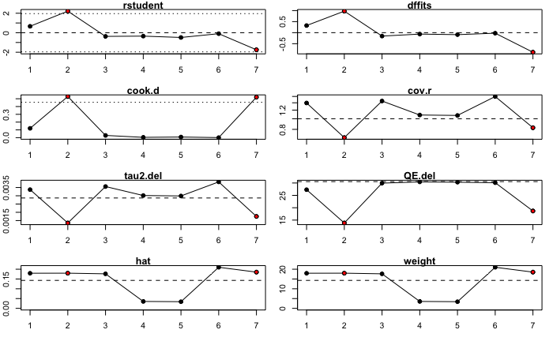

```r
plot(inf)
```

### make a forest plot to visualize the results

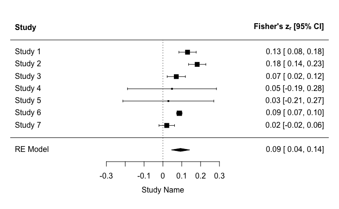

```r
forest(res, header=TRUE, xlab = 'Study Name')
```

### make a funnel plot to small study bias - assessing funnel plot asymmetry

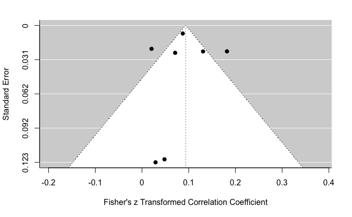

```r
funnel(res)
```

### run an Eggert’s Regression test (regtest) - a formal test to assess publication bias

```r
regtest(res)
```

```
Regression Test for Funnel Plot Asymmetry

Model:     mixed-effects meta-regression model
Predictor: standard error

Test for Funnel Plot Asymmetry: z = -0.4957, p = 0.6201
Limit Estimate (as sei -> 0):   b = 0.1058 (CI: 0.0351, 0.1765)
```

## Run a moderation analysis using res.modq

### look at child or adolescent (age) dummy variable to see if it has a moderating effect

```r
res.modage = rma(yi, vi, mods = ~ child.adolescent, data=efz)
res.modage
```

```
Mixed-Effects Model (k = 7; tau^2 estimator: REML)

tau^2 (estimated amount of residual heterogeneity):     0.0037 (SE = 0.0033)
tau (square root of estimated tau^2 value):             0.0608
I^2 (residual heterogeneity / unaccounted variability): 81.25%
H^2 (unaccounted variability / sampling variability):   5.33
R^2 (amount of heterogeneity accounted for):            0.00%

Test for Residual Heterogeneity:
QE(df = 5) = 30.0491, p-val < .0001

Test of Moderators (coefficient 2):
QM(df = 1) = 0.0983, p-val = 0.7539

Model Results:
```

|  | estimate | se | zval | pval | ci.lb | ci.ub |  |
| --- | --- | --- | --- | --- | --- | --- | --- |
| intrcpt | 0.0776 | 0.0559 | 1.3879 | 0.1652 | -0.0320 | 0.1872 |  |
| child.adolescent | 0.0201 | 0.0642 | 0.3135 | 0.7539 | -0.1057 | 0.1460 |  |

```
---
Signif. codes:  0 ‘***’ 0.001 ‘**’ 0.01 ‘*’ 0.05 ‘.’ 0.1 ‘ ’ 1
```

p-value of 0.7539 - no significant moderating effect of age

### look at US or non-US (location) dummy variable to see if it has a moderating effect

```r
res.modlocation = rma(yi, vi, mods = ~ US, data=efz)
res.modlocation
```

```
Mixed-Effects Model (k = 7; tau^2 estimator: REML)

tau^2 (estimated amount of residual heterogeneity):     0.0034 (SE = 0.0031)
tau (square root of estimated tau^2 value):             0.0584
I^2 (residual heterogeneity / unaccounted variability): 83.08%
H^2 (unaccounted variability / sampling variability):   5.91
R^2 (amount of heterogeneity accounted for):            0.00%

Test for Residual Heterogeneity:
QE(df = 5) = 28.9207, p-val < .0001

Test of Moderators (coefficient 2):
QM(df = 1) = 0.4911, p-val = 0.4834

Model Results:
```

|  | estimate | se | zval | pval | ci.lb | ci.ub |  |
| --- | --- | --- | --- | --- | --- | --- | --- |
| intrcpt | 0.1102 | 0.0361 | 3.0489 | 0.0023 | 0.0394 | 0.1810 | ** |
| US | -0.0374 | 0.0534 | -0.7008 | 0.4834 | -0.1421 | 0.0672 |  |

```
---
Signif. codes:  0 ‘***’ 0.001 ‘**’ 0.01 ‘*’ 0.05 ‘.’ 0.1 ‘ ’ 1
```

p-value of 0.4834 - no significant moderating effect of location

### look at proportion of sample that is males (gender) to see if it has a moderating effect

```r
res.modgender = rma(yi, vi, mods = ~ Proportion.Male, data=efz)
res.modgender
```

```
Mixed-Effects Model (k = 7; tau^2 estimator: REML)

tau^2 (estimated amount of residual heterogeneity):     0.0030 (SE = 0.0027)
tau (square root of estimated tau^2 value):             0.0548
I^2 (residual heterogeneity / unaccounted variability): 84.32%
H^2 (unaccounted variability / sampling variability):   6.38
R^2 (amount of heterogeneity accounted for):            0.00%

Test for Residual Heterogeneity:
QE(df = 5) = 24.9819, p-val = 0.0001

Test of Moderators (coefficient 2):
QM(df = 1) = 0.5508, p-val = 0.4580

Model Results:
```

|  | estimate | se | zval | pval | ci.lb | ci.ub |  |
| --- | --- | --- | --- | --- | --- | --- | --- |
| intrcpt | 0.1247 | 0.0492 | 2.5354 | 0.0112 | 0.0283 | 0.2211 | * |
| Proportion.Male | -0.0529 | 0.0712 | -0.7421 | 0.4580 | -0.1925 | 0.0868 |  |

```
---
Signif. codes:  0 ‘***’ 0.001 ‘**’ 0.01 ‘*’ 0.05 ‘.’ 0.1 ‘ ’ 1
```

p-value of 0.4580 - no significant moderating effect of gender

## use robust variance estimation - accounting for effect size dependencies (because there were two studies that reported two seperate effect sizes)

```r
mes_ss = robu(formula = yi ~ 1, data = efz, studynum = id,
              var.eff.size = vi, small = TRUE)
mes_ss
```

```
RVE: Correlated Effects Model with Small-Sample Corrections

Model: yi ~ 1

Number of studies = 5
Number of outcomes = 7 (min = 1 , mean = 1.4 , median = 1 , max = 2 )
Rho = 0.8
I.sq = 80.43772
Tau.sq = 0.001683382
```

|  |  | Estimate | StdErr | t-value | dfs | P(\|t\|>) | 95% CI.L | 95% CI.U | Sig |
| --- | --- | --- | --- | --- | --- | --- | --- | --- | --- |
| 1 | X.Intercept. | 0.082 | 0.0255 | 3.21 | 3.19 | 0.0447 | 0.00353 | 0.16 | ** |

```
---
Signif. codes: < .01 *** < .05 ** < .10 *
---
Note: If df < 4, do not trust the results
```

## Directly assessing publication bias using weightr

This selection model increases the weight of studies that are less likely to be published while decreases the weight of studies that are more likely to be published (based on publication bias of p-value)

```r
library(weightr)
wf = weightfunct(efz$yi, efz$vi, table = TRUE)
wf
```

```
Unadjusted Model (k = 7):

tau^2 (estimated amount of total heterogeneity): 0.0023 (SE = 0.0011)
tau (square root of estimated tau^2 value):  0.0481

Test for Heterogeneity:
Q(df = 6) = 30.5683, p-val = 7.466784e-05

Model Results:

          estimate std.error z-stat      p-val  ci.lb  ci.ub
Intercept  0.09286   0.02273  4.085 4.4152e-05 0.0483 0.1374

Adjusted Model (k = 7):

tau^2 (estimated amount of total heterogeneity): 0.0020 (SE = 0.0007)
tau (square root of estimated tau^2 value):  0.0451

Test for Heterogeneity:
Q(df = 6) = 30.5683, p-val = 7.466784e-05

Model Results:

              estimate std.error z-stat      p-val    ci.lb  ci.ub
Intercept       0.1069   0.02655 4.0268 5.6543e-05  0.05488  0.159
0.025 < p < 1   2.8575   4.10706 0.6958    0.48658 -5.19215 10.907

Likelihood Ratio Test:
X^2(df = 1) = 0.5551996, p-val = 0.4562

Number of Effect Sizes per Interval:

                     Frequency
p-values <0.025              4
0.025 < p-values < 1         3
```

Accounting for publication bias actually increases our effect size from .09286 to 0.1069. The chi-square test with a p-value of 0.4562 indicates no significant publication bias. A small sample makes this difficult to interpret overall.